# 函数

Humoon

2022-03-23

## Function

### 函数皆对象

R 中所有的函数都是对象，自定义函数都是一个赋值为对象的过程。

```r
add <- function(a, b) {
  a + b
}
add %>% class()
```

```
#> [1] "function"
```

```r
# 查看函数
add
```

```
#> function(a, b) {
#>   a + b
#> }
```

```r
# 调用函数
add(1, 3)
```

```
#> [1] 4
```

### 操作符皆函数

```r
head(iris)
```

```
#>   Sepal.Length Sepal.Width Petal.Length Petal.Width Species
#> 1          5.1         3.5          1.4         0.2  setosa
#> 2          4.9         3.0          1.4         0.2  setosa
#> 3          4.7         3.2          1.3         0.2  setosa
#> 4          4.6         3.1          1.5         0.2  setosa
#> 5          5.0         3.6          1.4         0.2  setosa
#> 6          5.4         3.9          1.7         0.4  setosa
```

```r
`[`(head(iris), 2) # 数据框的本质是list，筛选第二个元素，还是一个list
```

```
#>   Sepal.Width
#> 1         3.5
#> 2         3.0
#> 3         3.2
#> 4         3.1
#> 5         3.6
#> 6         3.9
```

```r
`[[`(head(iris), 2) # 提取第二个元素，是一个vector
```

```
#> [1] 3.5 3.0 3.2 3.1 3.6 3.9
```

```r
a <- 2:4
`[<-`(a, 2, 10) # a[2] <- 10; a
```

```
#> [1]  2 10  4
```

#### 常用操作符

##### 四则运算

加、减、乘(`*`)、除(`/`)、幂`^`, 除法取整（`%/%`）、除法取余（`%%`）

#### 自定义二元运算符

必须用反引号和百分号引起来

```r
`%myop%` <- function(a, b) {
  2 * a + 3 * b
}
1 %myop% 1
```

```
#> [1] 5
```

```r
1 %myop% 2
```

```
#> [1] 8
```

### 匿名函数

为了节省变量名，很多时候可以使用匿名函数。

匿名函数有几种写法，以 `purrr::map2()` 中为例：

```r
# 写法1，关键字 function 不缺，只省略了函数名的定义
map2_dbl(1:10, 11:20, function(x, y) y - x)
```

```
#>  [1] 10 10 10 10 10 10 10 10 10 10
```

```r
# 写法2，将关键字 function 简写为\
map2_dbl(1:10, 11:20, \(x, y) y - x)
```

```
#>  [1] 10 10 10 10 10 10 10 10 10 10
```

```r
# 写法3，用~代表匿名函数，.x(或.), .y代表自变量
map2_dbl(1:10, 11:20, ~ .y - .x)
```

```
#>  [1] 10 10 10 10 10 10 10 10 10 10
```

```r
map2_dbl(1:10, 11:20, ~ .y - .)
```

```
#>  [1] 10 10 10 10 10 10 10 10 10 10
```

**不建议使用 `~ .x` 的写法**，因为这种写法有两个缺陷：

1. 匿名函数最多有两个自变量，`.z`是不被认可的
2. 配合动态参数`...`一起使用时，**存在bug**，`...`会连写明的`.x`一起捕获

### 参数

```r
add(as.Date("2020-02-02"), 2)
```

```
#> [1] "2020-02-04"
```

#### 参数无定义

若函数的某个参数没有传递值，`missing(parameter)` 返回 TRUE

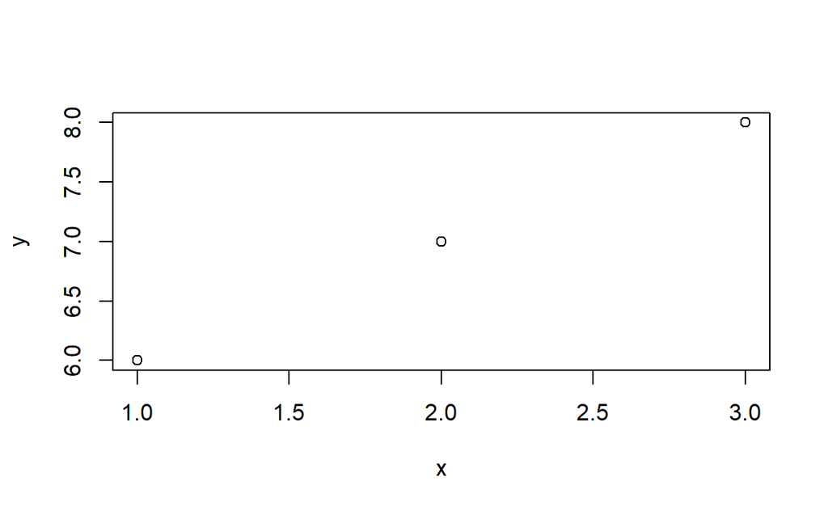

```r
myplot <- function(x, y) {
  if (missing(y)) {
    y <- x
    x <- 1:length(y)
  }
  plot(x, y)
}

myplot(c(6, 7, 8))
```

#### 参数默认值

默认值可以是一个值，也可以是一个表达式，其中包含了其前面定义的其他参数

```r
m <- 1:5
test3 <- function(x, n = floor(length(m) / 2)) {
  x[1:n]
}
test3(letters)
```

```
#> [1] "a" "b"
```

#### 动态参数

`...`能捕获任意数量的未匹配参数

##### 用法一：由一般函数特化而来的特殊函数

```r
# 最具一般性的函数，参数最完整，包含大量默认值
f <- function(x, t, u = 0, v = 0) {
  if (t == 1) {
    return(x + u + v)
  }
  if (t == 2) {
    return(x^2 + u + v)
  }
}

f(5, 1, 3, 2)
```

```
#> [1] 10
```

```r
f(5, 2, 3, 2)
```

```
#> [1] 30
```

```r
f(5, 1)
```

```
#> [1] 5
```

```r
f(5, 2)
```

```
#> [1] 25
```

```r
# 通过对一部分参数（t）的特化，实现一般基础上的特殊函数
# 为了简便，可以省略大量已有默认值的参数
g <- function(x, ...) {
  f(x, 1, ...)
}

h <- function(x, ...) {
  f(x, 2, ...)
}

g(5, 3, 2)
```

```
#> [1] 10
```

```r
h(5, 3, 2)
```

```
#> [1] 30
```

```r
g(5)
```

```
#> [1] 5
```

```r
h(5)
```

```
#> [1] 25
```

##### 用法二：捕获未知个数的参数

在函数内部，可以直接用`str_c()`将`...`合并为字符串（长度为1）

但也可以用`list(...)`将其转化为列表（长度一般大于1）再处理

```r
# 合并为字符串
rule <- function(..., pad = "=") {
  print(str_c(..., sep = " "))
  print(length(str_c(..., sep = " ")))
  args <- list(...)
  print(args)
  print(length(args))
  print(str_c(args, sep = " "))
  print(length(str_c(args, sep = " ")))


  title <- str_c(..., sep = " ")
  width <- getOption("width") - nchar(title) - 5
  cat(title, " ", stringr::str_dup(pad, width), "\n")
}
rule("Important", "output")
```

```
#> [1] "Important output"
#> [1] 1
#> [[1]]
#> [1] "Important"
#>
#> [[2]]
#> [1] "output"
#>
#> [1] 2
#> [1] "Important" "output"
#> [1] 2
#> Important output   ===========================================================
```

```r
# 读取为list
multip <- function(x, ...) {
  args <- list(...) ## 获取所有参数
  x + args[[1]] - args[[2]]
}
multip(3, 2, 3)
```

```
#> [1] 2
```

#### 惰性求值

在函数调用时，参数的值只有被实际用到时才会被执行。这样可以避免不必要的计算，节省时间。

```r
test0 <- function(x, y) {
  if (x > 0) {
    x
  } else {
    y
  }
}

# 生成大量随机数的耗时
system.time(rnorm(10000000))
```

```
#> 用户 系统 流逝
#> 0.66 0.00 0.65
```

```r
# 惰性求值，第二个参数并未执行
system.time(test0(1, rnorm(10000000)))
```

```
#> 用户 系统 流逝
#>    0    0    0
```

### 返回值

若无`return()`, 默认返回最后一个表达式的值

**R 风格的代码，通常省略 `return()`**

希望返回多个值时，一般用 list 或 dataframe 封装（就像 js 中用对象封装）

### 泛型函数

```r
calc <-
  function(x, y, type) {
    if (length(type > 1L)) {
      stop(" Only a single type is accepted")
    }

    if (type == "add") {
      x + y
    } else if (type == "minus") {
      x - y
    } else if (type == "multiply") {
      x * y
    } else if (type == "divide") {
      x / y
    } else {
      stop(" Unknown type of operation")
    }
  }
```